# Tugas Praktikum 5

Author

Muhammad Rafif Danuja

Published

October 8, 2025

# Import Library & Data

```r
library(ggplot2)
library(tsibble)
library(tseries)
library(MASS)
library(readxl)
library(lattice)
library(aTSA)
library(TTR)
library(forecast)
library(TSA)
library(dplyr)
```

```r
data <- read_excel("D:/IPB/Semester 5/MPDW/mpdw/Data praktikum/Rafif.xlsx")
data
```

```
# A tibble: 125 × 2
   Tanggal      Harga
   <chr>        <chr>
 1 Aug 28, 2025 9,300.00
 2 Aug 27, 2025 9,325.00
 3 Aug 26, 2025 9,375.00
 4 Aug 25, 2025 9,500.00
 5 Aug 22, 2025 9,575.00
 6 Aug 21, 2025 9,550.00
 7 Aug 20, 2025 9,650.00
 8 Aug 19, 2025 9,775.00
 9 Aug 15, 2025 9,900.00
10 Aug 14, 2025 9,725.00
# ℹ 115 more rows
```

```r
data$Harga <- as.numeric(gsub(",", "", data$Harga))
```

# Plot Time-Series

```r
data <- data %>%
  mutate(Tanggal = as.Date(Tanggal, format = "%b %d, %Y")) %>%
  arrange(Tanggal)
```

```r
head(data)
```

```
# A tibble: 6 × 2
  Tanggal    Harga
  <date>     <dbl>
1 2025-02-12 11150
2 2025-02-13 11225
3 2025-02-14 11525
4 2025-02-17 11500
5 2025-02-18 11525
6 2025-02-19 11650
```

```r
mean(data$Harga)
```

```
[1] 10506
```

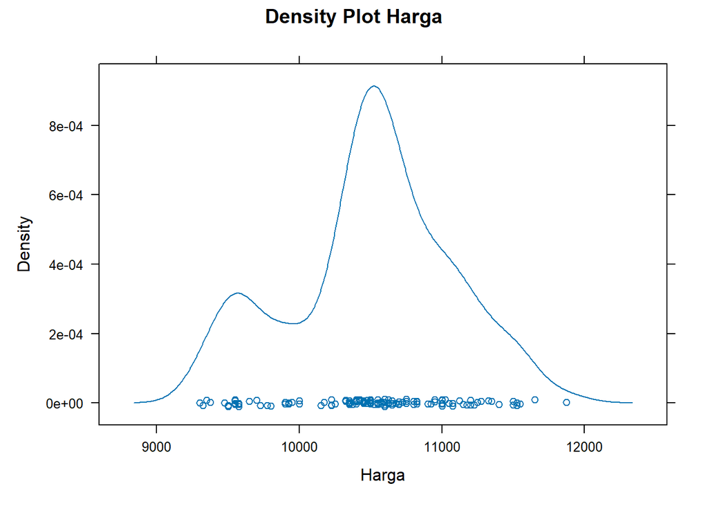

```r
densityplot(~ Harga, data = data,
            xlab = "Harga",
            main = "Density Plot Harga")
```

# Split Data

## Splitting

```r
length(data$Harga)
```

```
[1] 125
```

```r
train_data <- data[1:80, ]
test_data  <- data[81:nrow(data), ]
```

```r
train_data
```

```
# A tibble: 80 × 2
   Tanggal    Harga
   <date>     <dbl>
 1 2025-02-12 11150
 2 2025-02-13 11225
 3 2025-02-14 11525
 4 2025-02-17 11500
 5 2025-02-18 11525
 6 2025-02-19 11650
 7 2025-02-20 11550
 8 2025-02-21 11500
 9 2025-02-24 11875
10 2025-02-25 11325
# ℹ 70 more rows
```

## Plot Data

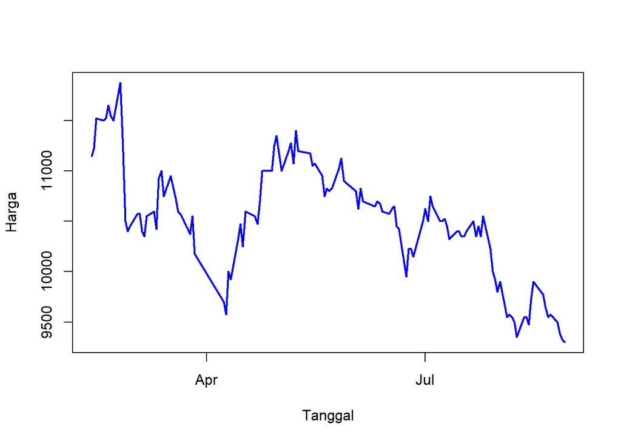

```r
plot(data$Tanggal, data$Harga, type = "l",
     xlab = "Tanggal", ylab = "Harga",
     col = "blue", lwd = 2)
```

## Plot Data Training

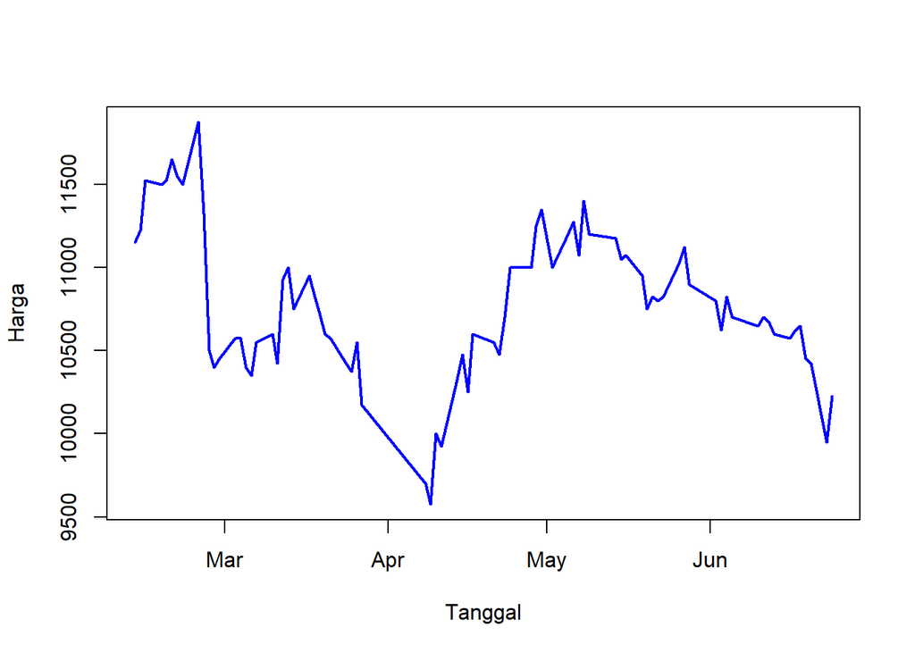

```r
plot(train_data$Tanggal, train_data$Harga, type = "l",
     xlab = "Tanggal", ylab = "Harga",
     col = "blue", lwd = 2)
```

## Plot Data Testing

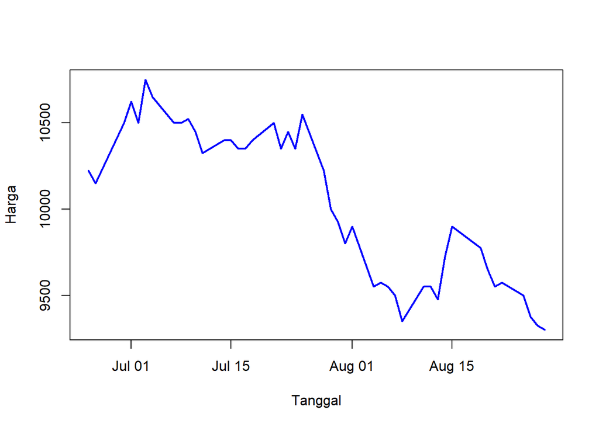

```r
plot(test_data$Tanggal, test_data$Harga, type = "l",
     xlab = "Tanggal", ylab = "Harga",
     col = "blue", lwd = 2)
```

# ACF

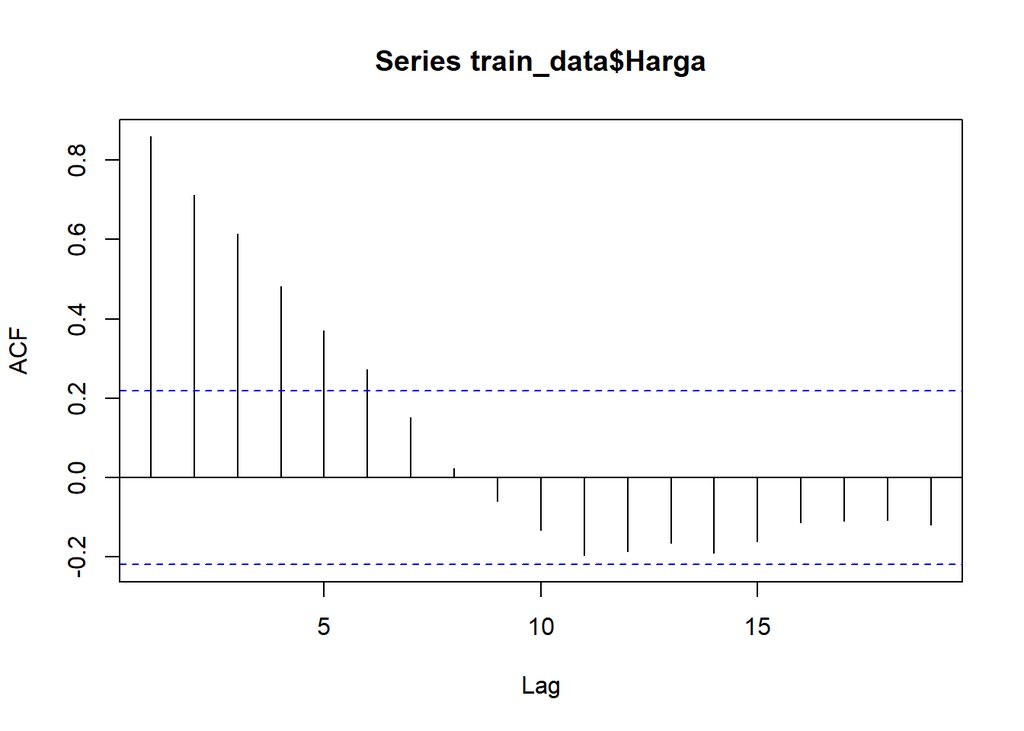

```r
acf(train_data$Harga)
```

Pola ACF turun berlahan, hal ini menunjukkan kalau data train kita belum stasioner.

```r
tseries::adf.test(train_data$Harga)
```

```
    Augmented Dickey-Fuller Test

data:  train_data$Harga
Dickey-Fuller = -2.4545, Lag order = 4, p-value = 0.3897
alternative hypothesis: stationary
```

Berdasarkan ADF test tersebut, nilai p value > 0.05. artinya kita gagal menolak hal nol, data train kita belum stasioner dalam rataan.

# Plot Box-cox

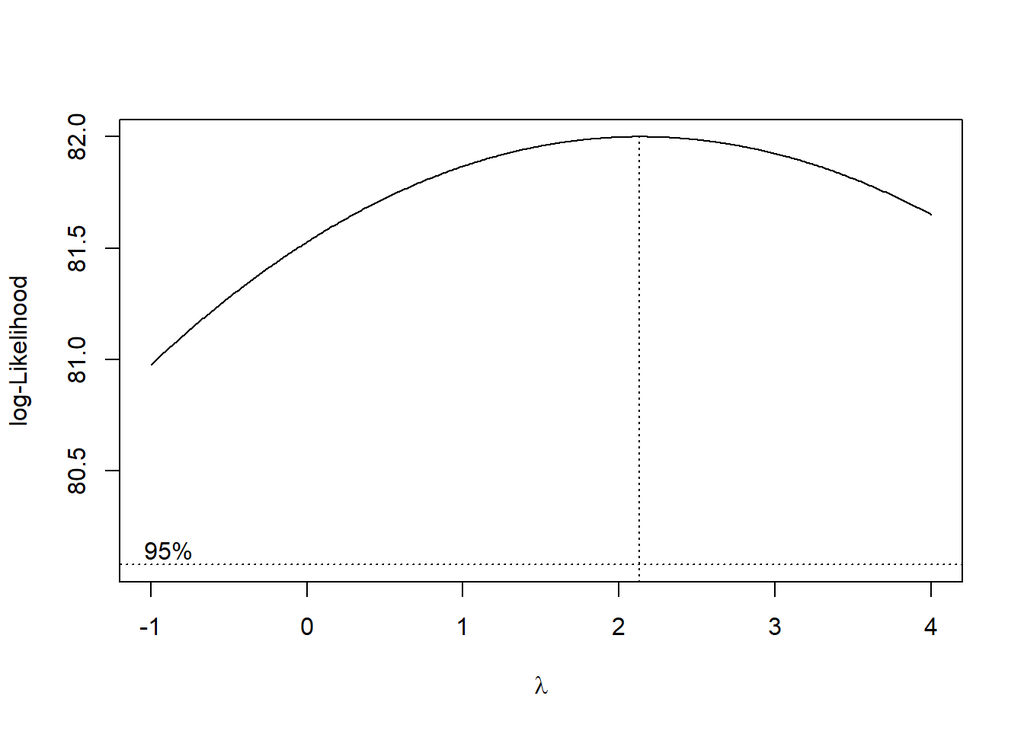

```r
stas <- train_data$Harga

index <- seq_along(stas)

lm_model <- lm(stas ~ index)

bc <- boxcox(
  lm_model,
  lambda = seq(-1, 4, by = 0.01)
)
```

```r
lambda <- bc$x[which.max(bc$y)]
lambda
```

```
[1] 2.13
```

```r
ci_lambda <- bc$x[bc$y > max(bc$y) - 0.5 * qchisq(0.95, 1)]

ci_lower <- min(ci_lambda)
ci_upper <- max(ci_lambda)

c(Batas_Bawah = ci_lower, Batas_Atas = ci_upper)
```

```
Batas_Bawah  Batas_Atas
         -1           4
```

Karena dalam selang kepercayaan terdapat lamda = 1, artinya model kita stasioner dalam ragam.

# Differencing

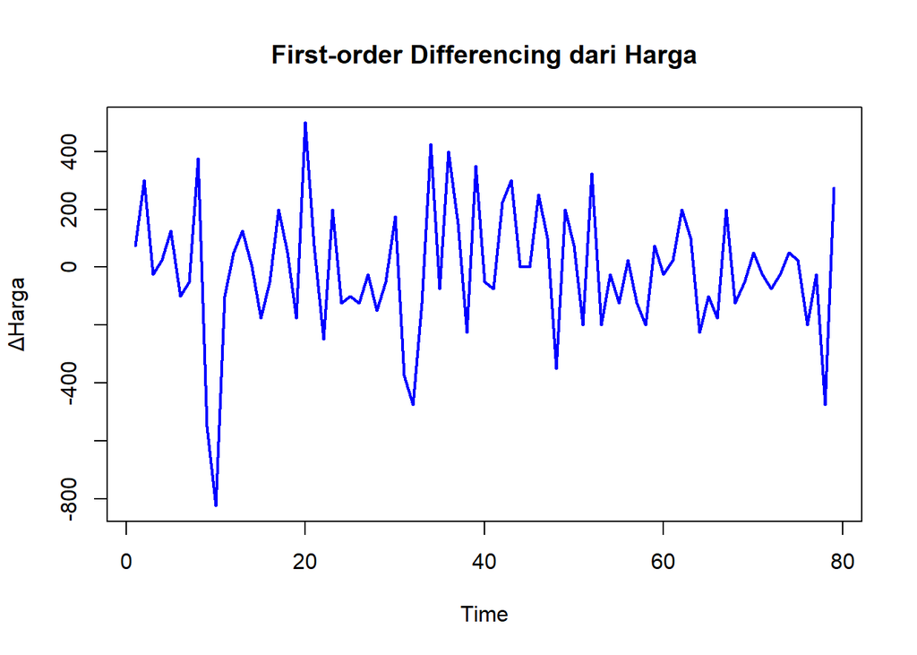

```r
stas_diff1 <- diff(stas, differences = 1)

ts.plot(stas_diff1,
        main = "First-order Differencing dari Harga",
        col = "blue", lwd = 2,
        ylab = "ΔHarga")
```

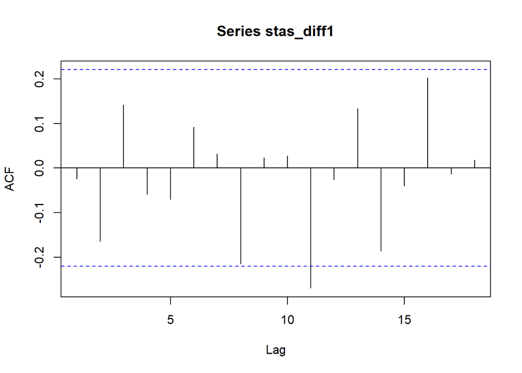

```r
acf(stas_diff1)
```

```r
tseries::adf.test(stas_diff1)
```

```
    Augmented Dickey-Fuller Test

data:  stas_diff1
Dickey-Fuller = -4.0327, Lag order = 4, p-value = 0.01255
alternative hypothesis: stationary
```

# Identifikasi Model

## ACF

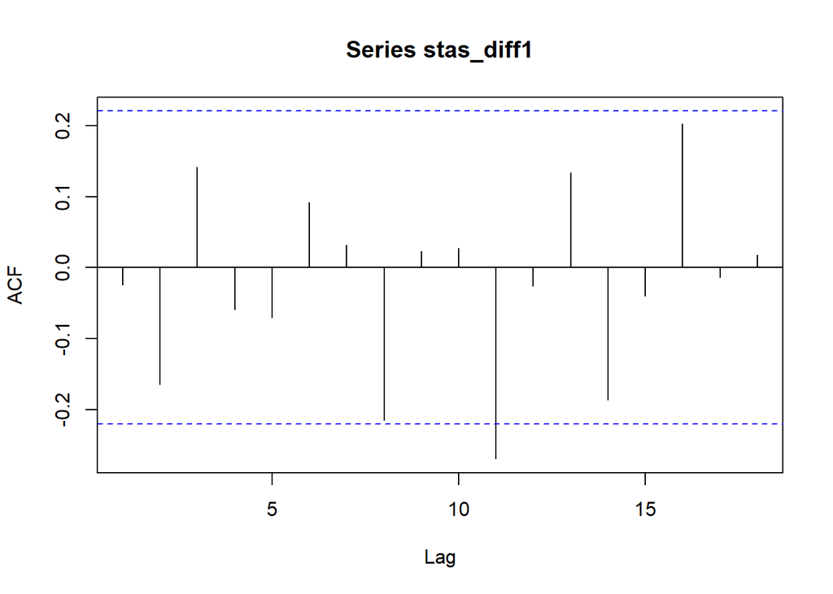

```r
acf(stas_diff1)
```

## PACF

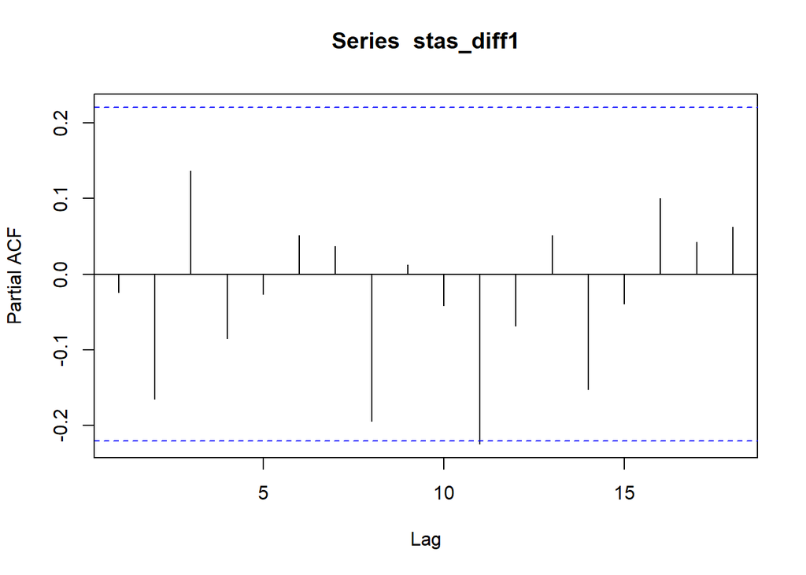

```r
pacf(stas_diff1)
```

## EACF

```r
eacf(stas_diff1)
```

```
AR/MA
  0 1 2 3 4 5 6 7 8 9 10 11 12 13
0 o o o o o o o o o o x  o  o  o
1 o o o o o o o o o o x  o  o  o
2 x o o o o o o o o o o  o  o  o
3 x o x o o o o o o o o  o  o  o
4 o x o o o o o o o o o  o  o  o
5 x o o x o o o o o o o  o  o  o
6 x o o x o o o o o o o  o  o  o
7 o o o o o o o o o o o  o  o  o
```

dari ACF, PACF, dan EACF didapatkan beberapa model tentatif : 1. ARIMA(0,1,1) 2. ARIMA(1,1,0) 3. ARIMA(1,1,1)

# Pendugaan Parameter Model Tentatif

```r
train_ts <- ts(train_data$Harga)
```

## ARIMA(0,1,1)

```r
model1.da=Arima(train_ts, order=c(0,1,1),method="ML")
summary(model1.da)
```

```
Series: train_ts
ARIMA(0,1,1)

Coefficients:
          ma1
      -0.0294
s.e.   0.1344

sigma^2 = 50876:  log likelihood = -539.66
AIC=1083.32   AICc=1083.48   BIC=1088.06

Training set error measures:
                    ME   RMSE      MAE        MPE     MAPE      MASE
Training set -11.87262 222.72 164.4757 -0.1336627 1.538116 0.9899874
                    ACF1
Training set 0.000653712
```

```r
lmtest::coeftest(model1.da)
```

```
z test of coefficients:

    Estimate Std. Error z value Pr(>|z|)
ma1 -0.02940    0.13441 -0.2187   0.8269
```

model dengan ma(1) tidak signifikan.

## ARIMA(1,1,0)

```r
model2.da=Arima(train_ts, order=c(1,1,0),method="ML")
summary(model2.da)
```

```
Series: train_ts
ARIMA(1,1,0)

Coefficients:
          ar1
      -0.0203
s.e.   0.1129

sigma^2 = 50886:  log likelihood = -539.67
AIC=1083.33   AICc=1083.49   BIC=1088.07

Training set error measures:
                    ME     RMSE      MAE        MPE     MAPE    MASE
Training set -11.72791 222.7416 164.4047 -0.1320894 1.537333 0.98956
                     ACF1
Training set -0.006918268
```

```r
lmtest::coeftest(model2.da)
```

```
z test of coefficients:

     Estimate Std. Error z value Pr(>|z|)
ar1 -0.020306   0.112929 -0.1798   0.8573
```

model dengan AR(1) tidak signifikan

## ARIMA(1,1,1)

```r
model3.da=Arima(train_ts, order=c(1,1,1),method="ML")
summary(model3.da)
```

```
Series: train_ts
ARIMA(1,1,1)

Coefficients:
         ar1      ma1
      0.8971  -1.0000
s.e.  0.0588   0.0537

sigma^2 = 48942:  log likelihood = -538.45
AIC=1082.9   AICc=1083.22   BIC=1090.01

Training set error measures:
                   ME     RMSE      MAE       MPE     MAPE      MASE       ACF1
Training set -25.0763 217.0412 162.4026 -0.266214 1.521349 0.9775087 0.01935412
```

```r
lmtest::coeftest(model3.da)
```

```
z test of coefficients:

     Estimate Std. Error z value  Pr(>|z|)
ar1  0.897077   0.058820  15.251 < 2.2e-16 ***
ma1 -0.999999   0.053708 -18.619 < 2.2e-16 ***
---
Signif. codes:  0 '***' 0.001 '**' 0.01 '*' 0.05 '.' 0.1 ' ' 1
```

AR(1) dan MA(1) signifikan

## Perbandingan Model

```r
aic.arima<-data.frame(
  "Model"=c("ARIMA(0,1,1)", "ARIMA(1,1,0)", "ARIMA(1,1,1)"),
  "AIC"=c(model1.da$aic, model2.da$aic, model3.da$aic))

aic.arima
```

```
         Model      AIC
1 ARIMA(0,1,1) 1083.319
2 ARIMA(1,1,0) 1083.334
3 ARIMA(1,1,1) 1082.902
```

Model ARIMA(1,1,1) memiliki nilai AIC ter-rendah.

# Diagnostik Model

## Uji non-Formal

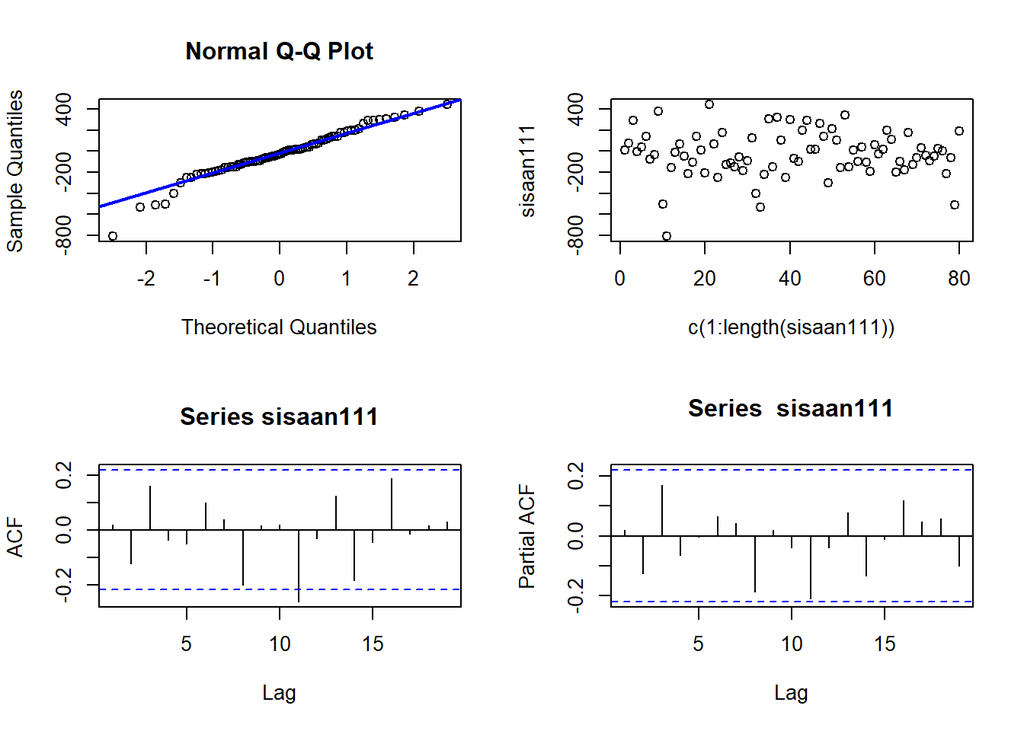

```r
arima.111y<-Arima(train_ts,   order=c(1,1,1), include.mean = TRUE,method="ML")
sisaan111 <- arima.111y$residuals

# Eksplorasi
par(mfrow=c(2,2))
qqnorm(sisaan111)
qqline(sisaan111, col = "blue", lwd = 2)
plot(c(1:length(sisaan111)),sisaan111)
acf(sisaan111)
pacf(sisaan111)
```

## Uji Non-Autokorelasi

```r
Box.test(sisaan111, lag = 23 ,type = "Ljung")
```

```
    Box-Ljung test

data:  sisaan111
X-squared = 29.758, df = 23, p-value = 0.1565
```

Asumsi Non-Autokorelasi terpenuhi, hal ini dapat dilihat dari nilai p-value>0.05.

## Uji Normalitas

```r
ks.test(sisaan111,"pnorm")
```

```
    Exact one-sample Kolmogorov-Smirnov test

data:  sisaan111
D = 0.5375, p-value < 2.2e-16
alternative hypothesis: two-sided
```

P-value<0.05, artinya kita menolak h0. hal ini menunjukkan pelanggaran asumsi normalitas residual.

## Uji Nilai Tengah Sisaan

```r
t.test(sisaan111, mu = 0, alternative = "two.sided")
```

```
    One Sample t-test

data:  sisaan111
t = -1.0338, df = 79, p-value = 0.3044
alternative hypothesis: true mean is not equal to 0
95 percent confidence interval:
 -73.35570  23.20309
sample estimates:
mean of x
 -25.0763
```

Asumsi nilai harapan residual=0 terpenuhi.

# Overfitting Model

Overfitting model dilakukan pada model : 1. ARIMA(2,1,1) 2. ARIMA(1,1,2)

```r
arima.211<-arima(train_ts, order=c(2,1,1), include.mean = TRUE,method="ML") #ARIMA (2,1,1)

lmtest::coeftest(arima.211)
```

```
z test of coefficients:

    Estimate Std. Error z value Pr(>|z|)
ar1 -0.76386    0.25780 -2.9630 0.003046 **
ar2 -0.18886    0.12833 -1.4717 0.141102
ma1  0.79981    0.25376  3.1518 0.001623 **
---
Signif. codes:  0 '***' 0.001 '**' 0.01 '*' 0.05 '.' 0.1 ' ' 1
```

AR(2) tidak signifikan

```r
arima.112<-arima(train_ts, order=c(1,1,2), include.mean = TRUE,method="ML") #ARIMA (1,1,2)

lmtest::coeftest(arima.112)
```

```
z test of coefficients:

    Estimate Std. Error z value Pr(>|z|)
ar1 -0.57997    0.27721 -2.0922  0.03642 *
ma1  0.62016    0.28048  2.2111  0.02703 *
ma2 -0.20403    0.13230 -1.5422  0.12303
---
Signif. codes:  0 '***' 0.001 '**' 0.01 '*' 0.05 '.' 0.1 ' ' 1
```

MA(2) tidak signifikan

# Ukuran keakuratan ramalan Model ARIMA (1,1,1)

```r
length(fitted(arima.111y))
```

```
[1] 80
```

```r
nrow(train_data)
```

```
[1] 80
```

```r
dugaan <- fitted(arima.111y)
cbind(train_data,dugaan)
```

```
      Tanggal Harga    dugaan
1  2025-02-12 11150 11138.850
2  2025-02-13 11225 11151.955
3  2025-02-14 11525 11228.669
4  2025-02-17 11500 11505.014
5  2025-02-18 11525 11483.427
6  2025-02-19 11650 11509.880
7  2025-02-20 11550 11623.486
8  2025-02-21 11500 11531.618
9  2025-02-24 11875 11493.563
10 2025-02-25 11325 11827.829
11 2025-02-26 10500 11310.545
12 2025-02-27 10400 10553.400
13 2025-02-28 10450 10460.880
14 2025-03-03 10575 10506.668
```

[output cut: 66 more lines]

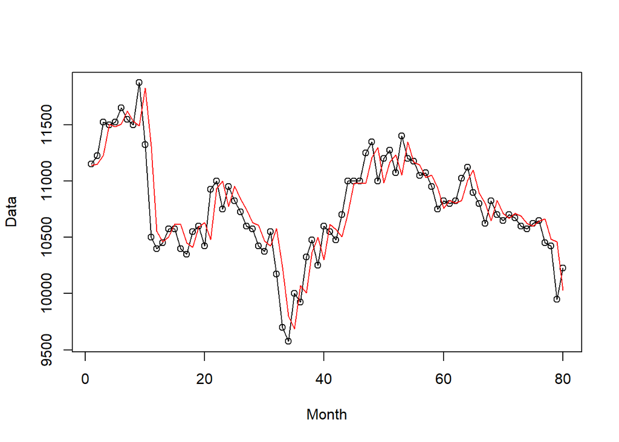

```r
plot.ts(train_data$Harga, xlab="Month", ylab="Data")
points(train_data$Harga)
par(col="red")
lines(dugaan)
```

```r
mape_train <- mean(abs((train_data$Harga - dugaan) / train_data$Harga)) * 100
mape_train
```

```
[1] 1.521349
```

Nilai MAPE pada train sangat baik, kurang dari 10%

```r
par(col="black")
```

```r
n_test <- nrow(test_data)
n_test
```

```
[1] 45
```

```r
forecast_test <- forecast(arima.111y, h = n_test)
forecast_test
```

```
    Point Forecast     Lo 80    Hi 80    Lo 95    Hi 95
 81       10279.81  9994.844 10564.78 9843.991 10715.63
 82       10328.98  9944.225 10713.74 9740.548 10917.41
 83       10373.09  9922.372 10823.81 9683.776 11062.40
 84       10412.66  9913.974 10911.35 9649.986 11175.33
 85       10448.16  9912.989 10983.32 9629.688 11266.63
 86       10480.00  9916.337 11043.66 9617.952 11342.05
 87       10508.57  9922.244 11094.89 9611.863 11405.27
 88       10534.19  9929.613 11138.77 9609.569 11458.82
 89       10557.18  9937.742 11176.62 9609.831 11504.53
 90       10577.80  9946.169 11209.44 9611.802 11543.80
 91       10596.30  9954.588 11238.02 9614.885 11577.72
 92       10612.90  9962.801 11263.00 9618.661 11607.14
 93       10627.79  9970.680 11284.89 9622.829 11632.74
 94       10641.14  9978.145 11304.14 9627.176 11655.11
```

[output cut: 31 more lines]

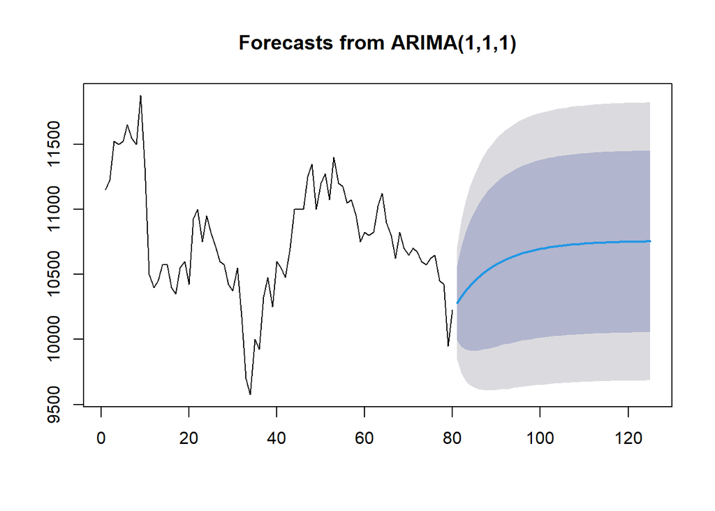

```r
plot(forecast_test)
```

```r
# Ambil nilai ramalan dan batasnya
ramalan <- as.numeric(forecast_test$mean)
lo80 <- as.numeric(forecast_test$lower[,1])
hi80 <- as.numeric(forecast_test$upper[,1])
lo95 <- as.numeric(forecast_test$lower[,2])
hi95 <- as.numeric(forecast_test$upper[,2])

# Gabungkan dengan data aktual (test_data)
gabungan2 <- data.frame(
  "Data Aktual Harga Emas" = test_data$Harga,
  "Ramalan" = ramalan,
  "Lo 80" = lo80,
  "Hi 80" = hi80,
  "Lo 95" = lo95,
  "Hi 95" = hi95
)

gabungan2
```

```
   Data.Aktual.Harga.Emas  Ramalan     Lo.80    Hi.80    Lo.95    Hi.95
1                   10225 10279.81  9994.844 10564.78 9843.991 10715.63
2                   10150 10328.98  9944.225 10713.74 9740.548 10917.41
3                   10500 10373.09  9922.372 10823.81 9683.776 11062.40
4                   10625 10412.66  9913.974 10911.35 9649.986 11175.33
5                   10500 10448.16  9912.989 10983.32 9629.688 11266.63
6                   10750 10480.00  9916.337 11043.66 9617.952 11342.05
7                   10650 10508.57  9922.244 11094.89 9611.863 11405.27
8                   10500 10534.19  9929.613 11138.77 9609.569 11458.82
9                   10500 10557.18  9937.742 11176.62 9609.831 11504.53
10                  10525 10577.80  9946.169 11209.44 9611.802 11543.80
11                  10450 10596.30  9954.588 11238.02 9614.885 11577.72
12                  10325 10612.90  9962.801 11263.00 9618.661 11607.14
13                  10400 10627.79  9970.680 11284.89 9622.829 11632.74
14                  10400 10641.14  9978.145 11304.14 9627.176 11655.11
```

[output cut: 31 more lines]

```r
mape_test <- mean(abs((test_data$Harga - ramalan) / test_data$Harga)) * 100
mape_test
```

```
[1] 6.799428
```

Performa model ARIMA(1,1,1) sangat baik dengan nilai MAPE 6.8%, meskipun nilai MAPE meningkat di data testing, akan tetapi model kita masih cukup handal dalam melakukan peramalan.